# Business Distribution and Employment Trends in Melbourne (2022)

**Authored by:** Aishwarya Mahajan  
**Level:** Intermediate **Focus-Area:** Business & Activity **Pre-requisite Skills:** Python, Data Analysis, Data Visualization

## Scenario

Understanding the distribution of businesses across Melbourne and the employment trends they generate is vital for sustainable city planning and economic growth. By analyzing business sizes and the employment they generate across different sectors, we can determine which industries drive job creation and identify the geographic areas that could benefit from policy support. This analysis focuses on examining the relationship between business size and employment in various industries within Melbourne, enabling better decision-making for urban development and economic policy.

## User Story

As a city planner and economist, I am committed to understanding how business size impacts job creation across Melbourne's industries. By analyzing the distribution of businesses and employment patterns, I can uncover key insights into Melbourne's economic landscape. This investigation aims to answer the following questions:

- Which business sizes contribute most to job creation in Melbourne?
- How can we predict the total number of jobs in different sectors?

## What This Use Case Will Teach

At the end of this use case, you will:

## Introduction

Two primary datasets will be used in this analysis: business establishments and jobs data by business size, and business establishments’ location and industry classification. These datasets will help us explore the factors contributing to business distribution and employment generation.

## Datasets

### 1. **Business Establishments and Jobs by Business Size and Industry**

- **Dataset URL:** [Business Establishments and Jobs by Business Size and Industry (2022)](https://data.melbourne.vic.gov.au/explore/dataset/business-establishments-and-jobs-data-by-business-size-and-industry/api/)
- **Features:** Business size (non-employing, small, medium, and large businesses), industry classification, number of jobs.
- **Usage:** This dataset will be used to analyze how different business sizes contribute to employment across industries.

### 2. **Business Establishments Location and Industry Classification**

- **Dataset URL:** [Business Establishments Location and Industry Classification (2022)](https://data.melbourne.vic.gov.au/explore/dataset/business-establishments-with-address-and-industry-classification/table/?refine.census_year=2021)
- **Features:** Location of businesses, industry classification (ANZSIC4), business address.
- **Usage:** This dataset will provide insights into the geographic distribution of businesses in Melbourne by industry.

## Conclusion

This project aims to provide a comprehensive view of business distribution and employment patterns in Melbourne, offering actionable insights to city planners and policymakers. By analyzing business size and distribution, we can better understand Melbourne’s economic landscape and identify areas where further growth and development can be encouraged.

## Importing necessary Libraries

```python
import requests
import pandas as pd
from io import StringIO
from sklearn.tree import DecisionTreeRegressor
from sklearn.ensemble import RandomForestRegressor
from sklearn.metrics import mean_squared_error, r2_score
import numpy as np
import seaborn as sns
import matplotlib.pyplot as plt
from sklearn.preprocessing import LabelEncoder
from sklearn.model_selection import train_test_split
from sklearn.linear_model import LinearRegression
```

## Data Retrieval using base url and dataset ids

```python
# Function to collect data
def collect_data(dataset_id):
    base_url = 'https://data.melbourne.vic.gov.au/api/explore/v2.1/catalog/datasets/'
    format = 'csv'
    url = f'{base_url}{dataset_id}/exports/{format}'
    params = {
        'select': '*',
        'limit': -1,  # retrieve all records
        'lang': 'en',
        'timezone': 'UTC',
    }

    # GET request to the dataset API
    response = requests.get(url, params=params)

    if response.status_code == 200:
        # Decoding the content and reading into a pandas dataframe
        url_content = response.content.decode('utf-8')
        # Detecting delimiter
        delimiter = ','
        sample_lines = url_content.split('\n')[:5]
        for line in sample_lines:
            if ';' in line:
                delimiter = ';'
                break
        # Reading data into a pandas DataFrame
        df = pd.read_csv(StringIO(url_content), delimiter=delimiter)
        print(f'Successfully retrieved dataset: {dataset_id}')
        return df
    else:
        print(f'Request failed with status code {response.status_code}')
        return None

# Dataset IDs for business-related data
dataset_ids = {
    'business_establishments': 'business-establishments-with-address-and-industry-classification',
    'jobs_by_business_size': 'business-establishments-and-jobs-data-by-business-size-and-industry'
}

# Collecting and printing data for each dataset
datasets = {}
for name, dataset_id in dataset_ids.items():
    print(f"\nCollecting data for {name}...")
    df = collect_data(dataset_id)
    if df is not None:
        datasets[name] = df
        print(f"The {name} dataset contains {len(df)} records.")
        print(df.head(3))
    else:
        print(f"Failed to retrieve the {name} dataset.")

# Assigning the datasets to variables
Business_df = datasets.get('business_establishments')
Jobs_df = datasets.get('jobs_by_business_size')

# You can further analyze or manipulate the `Business_df` and `Jobs_df` DataFrames as needed
```

```
Successfully retrieved dataset: business-establishments-with-address-and-industry-classification
The business_establishments dataset contains 374210 records.
   census_year  block_id  property_id  base_property_id clue_small_area  \
0         2017       266       109851            109851         Carlton
1         2017       266       109851            109851         Carlton
2         2017       266       534003            534003         Carlton

                   trading_name                          business_address  \
0  Metropoli's Research Pty Ltd  Level 1, 74 Victoria Street CARLTON 3053
1             J Hong Restaurant  Ground , 74 Victoria Street CARLTON 3053
2                  St2 Expresso           70 Victoria Street CARLTON 3053

   industry_anzsic4_code              industry_anzsic4_description  \
0                   6950  Market Research and Statistical Services
1                   4511                     Cafes and Restaurants
2                   4512                    Takeaway Food Services

    longitude   latitude
0  144.965352 -37.806701
1  144.965352 -37.806701
2  144.965473 -37.806714

Successfully retrieved dataset: business-establishments-and-jobs-data-by-business-size-and-industry
The jobs_by_business_size dataset contains 14692 records.
   census_year               clue_small_area  \
0         2015  West Melbourne (Residential)
1         2015  West Melbourne (Residential)
2         2015  West Melbourne (Residential)

                     anzsic_indusrty                      clue_industry  \
0  Health Care and Social Assistance  Health Care and Social Assistance
1                      Manufacturing                      Manufacturing
2                      Manufacturing                      Manufacturing

     business_size  total_establishments  total_jobs
0   Large business                     1         NaN
1  Medium business                     5       171.0
2    Non employing                     1         NaN
```

## Initial EDA for both datasets

```python
# Initial EDA for Business_df
if Business_df is not None:
    num_rows_business, num_cols_business = Business_df.shape
    print("Rows in the Business_df:", num_rows_business)
    print("Columns in the Business_df:", num_cols_business)
    print(Business_df.head())  # Display the first few rows of the Business dataset

# Initial EDA for Jobs_df
if Jobs_df is not None:
    num_rows_jobs, num_cols_jobs = Jobs_df.shape
    print("Rows in the Jobs_df:", num_rows_jobs)
    print("Columns in the Jobs_df:", num_cols_jobs)
    print(Jobs_df.head())  # Display the first few rows of the Jobs dataset
```

```
Rows in the Business_df: 374210
Columns in the Business_df: 11
   census_year  block_id  property_id  base_property_id clue_small_area  \
0         2017       266       109851            109851         Carlton
1         2017       266       109851            109851         Carlton
2         2017       266       534003            534003         Carlton
3         2017       266       664003            664003         Carlton
4         2017       266       664005            664005         Carlton

                   trading_name                          business_address  \
0  Metropoli's Research Pty Ltd  Level 1, 74 Victoria Street CARLTON 3053
1             J Hong Restaurant  Ground , 74 Victoria Street CARLTON 3053
2                  St2 Expresso           70 Victoria Street CARLTON 3053
3            RMIT Resources Ltd           20 Cardigan Street CARLTON 3053
4                        vacant           24 Cardigan Street CARLTON 3053

   industry_anzsic4_code              industry_anzsic4_description  \
0                   6950  Market Research and Statistical Services
1                   4511                     Cafes and Restaurants
2                   4512                    Takeaway Food Services
3                   8102                          Higher Education
4                      0                              Vacant Space

    longitude   latitude
0  144.965352 -37.806701
1  144.965352 -37.806701
2  144.965473 -37.806714
3  144.964753 -37.806312
4  144.964772 -37.806203
Rows in the Jobs_df: 14692
Columns in the Jobs_df: 7
   census_year               clue_small_area  \
0         2015  West Melbourne (Residential)
1         2015  West Melbourne (Residential)
2         2015  West Melbourne (Residential)
3         2015  West Melbourne (Residential)
4         2015  West Melbourne (Residential)

                                   anzsic_indusrty  \
0                Health Care and Social Assistance
1                                    Manufacturing
2                                    Manufacturing
3  Professional, Scientific and Technical Services
4          Rental, Hiring and Real Estate Services

                       clue_industry    business_size  total_establishments  \
0  Health Care and Social Assistance   Large business                     1
1                      Manufacturing  Medium business                     5
2                      Manufacturing    Non employing                     1
3                  Business Services    Non employing                     3
4               Real Estate Services   Small business                     5

   total_jobs
0         NaN
1       171.0
2         NaN
3         0.0
4        42.0
```

## Filtering data for year 2022 for evaluation

```python
# Filtering the Business_df for Census year 2022
Business_2022_df = Business_df[Business_df['census_year'] == 2022]

# Filtering the Jobs_df for Census year 2022
Jobs_2022_df = Jobs_df[Jobs_df['census_year'] == 2022]

# Displaying the shapes of the filtered dataframes
print(f"Filtered Business_2022_df: {Business_2022_df.shape}")
print(Business_2022_df.head())
print(f"Filtered Jobs_2022_df: {Jobs_2022_df.shape}")
print(Jobs_2022_df.head())
```

```
Filtered Business_2022_df: (19660, 11)
       census_year  block_id  property_id  base_property_id clue_small_area  \
63745         2022      1108       604119            604119       Docklands
63746         2022      1108       604119            604119       Docklands
63747         2022      1108       604119            604119       Docklands
63748         2022      1108       604119            604119       Docklands
63749         2022      1108       604124            604124       Docklands

                       trading_name  \
63745  Melbourne Private Apartments
63746    Dock 5 Building Management
63747               VinTam's Bakery
63748                        Vacant
63749                   Barry Plant

```

[output cut: 34 more lines]

## Implementing Data Cleaning using below steps.

1. **Removing Unwanted Columns**: Non-essential columns, such as `block_id`, `property_id`, and `longitude`, were dropped to keep only the relevant data for business and employment analysis.
2. **Checking Missing Values**: Missing values in critical columns were identified, particularly in the `Total jobs` column of the jobs dataset.
3. **Checking Skewness and Plotting Visualization**: Skewness of the `Total jobs` column was calculated, and a histogram was plotted to assess the distribution. Due to the high positive skewness, the median was selected as the most appropriate method for imputing missing values.

```python
# Dropping irrelevant columns from Business_df
Business_2022_df = Business_2022_df.drop(columns=['block_id', 'property_id', 'base_property_id', 'longitude', 'latitude'])

# Dropping irrelevant columns from Jobs_df
Jobs_2022_df = Jobs_2022_df.drop(columns=['clue_industry'])

# Displaying the shapes and first few rows of the cleaned dataframes
print(f"Cleaned Business_2022_df: {Business_2022_df.shape}")
print(Business_2022_df.head())

print(f"Cleaned Jobs_2022_df: {Jobs_2022_df.shape}")
print(Jobs_2022_df.head())
```

```
Cleaned Business_2022_df: (19660, 6)
       census_year clue_small_area                  trading_name  \
63745         2022       Docklands  Melbourne Private Apartments
63746         2022       Docklands    Dock 5 Building Management
63747         2022       Docklands               VinTam's Bakery
63748         2022       Docklands                        Vacant
63749         2022       Docklands                   Barry Plant

                                   business_address  industry_anzsic4_code  \
63745        105 Merchant Street DOCKLANDS VIC 3008                   6720
63746        103 Merchant Street DOCKLANDS VIC 3008                   6720
63747    107-109 Merchant Street DOCKLANDS VIC 3008                   4511
63748       28 Cumberland Street DOCKLANDS VIC 3008                      0
63749  Shop 8, 818 Bourke Street DOCKLANDS VIC 3008                   6720

```

[output cut: 20 more lines]

## Checking missing values

```python
# Check for missing values in Business_2022_df
missing_values_business = Business_2022_df.isnull().sum()

# Check for missing values in Jobs_2022_df
missing_values_jobs = Jobs_2022_df.isnull().sum()

# Print the missing values in Business_2022_df
print("Missing values in Business_2022_df:")
print(missing_values_business)

# Print the missing values in Jobs_2022_df
print("\nMissing values in Jobs_2022_df:")
print(missing_values_jobs)
```

```
Missing values in Business_2022_df:
census_year                     0
clue_small_area                 0
trading_name                    0
business_address                0
industry_anzsic4_code           0
industry_anzsic4_description    0
dtype: int64

Missing values in Jobs_2022_df:
census_year               0
clue_small_area           0
anzsic_indusrty           0
business_size             0
total_establishments      0
total_jobs              218
dtype: int64
```

## Evaluating Skewness and Plotting Histogram

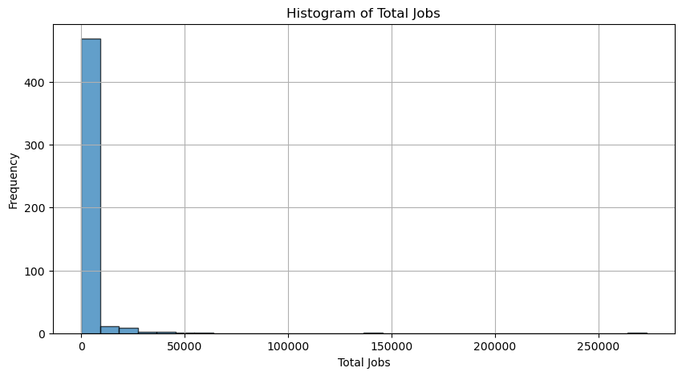

```
Skewness of 'Total jobs': 13.942711140182322
```

```python
# Draw histogram and calculate skewness for 'Total jobs' in Jobs_2022_df
plt.figure(figsize=(10, 5))
plt.hist(Jobs_2022_df['total_jobs'].dropna(), bins=30, edgecolor='k', alpha=0.7)
plt.title('Histogram of Total Jobs')
plt.xlabel('Total Jobs')
plt.ylabel('Frequency')
plt.grid(True)
plt.show()

# Calculate skewness for 'Total jobs'
jobs_skewness = Jobs_2022_df['total_jobs'].dropna().skew()
print(f"Skewness of 'Total jobs': {jobs_skewness}\n")
```

A skewness value of **13.94** indicates that the distribution of **Total jobs** is highly positively skewed, meaning there are a few businesses with a very large number of jobs, while most businesses have fewer jobs.

Given this high skewness, it’s likely better to impute the missing values using the **median**, which is less affected by outliers compared to the mean.

```python
# Imputing missing values in 'Total jobs' with the median
Jobs_2022_df['total_jobs'].fillna(Jobs_2022_df['total_jobs'].median(), inplace=True)

# Check for missing values after imputation
missing_values_after_imputation = Jobs_2022_df.isnull().sum()
print("Missing values after imputation in Jobs_2022_df:")
print(missing_values_after_imputation)
```

```
Missing values after imputation in Jobs_2022_df:
census_year             0
clue_small_area         0
anzsic_indusrty         0
business_size           0
total_establishments    0
total_jobs              0
dtype: int64
```

## Significant Analyses and Visualizing data

### Visualizing total jobs by business size

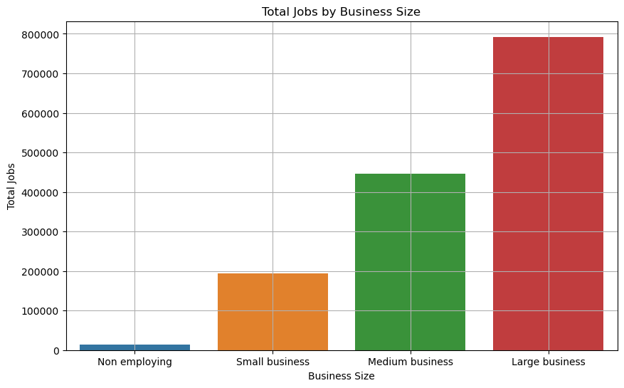

```python
#  Total jobs by business size
plt.figure(figsize=(10, 6))
sns.barplot(data=Jobs_2022_df, x='business_size', y='total_jobs', estimator=sum, ci=None)
plt.title('Total Jobs by Business Size')
plt.xlabel('Business Size')
plt.ylabel('Total Jobs')
plt.grid(True)
plt.show()
```

## Visualizing total jobs by industry

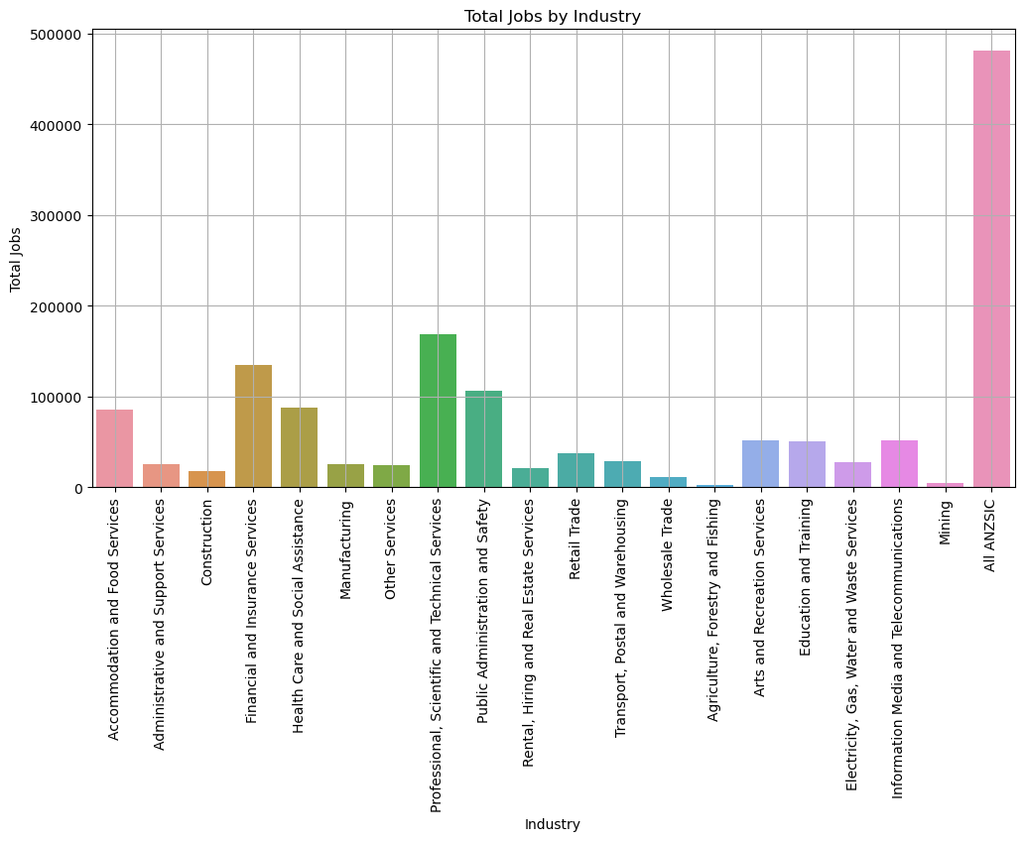

```python
# Total jobs by industry
plt.figure(figsize=(12, 6))
sns.barplot(data=Jobs_2022_df, x='anzsic_indusrty', y='total_jobs', estimator=sum, ci=None)
plt.title('Total Jobs by Industry')
plt.xlabel('Industry')
plt.ylabel('Total Jobs')
plt.xticks(rotation=90)
plt.grid(True)
plt.show()
```

## Visualizing relationship between business size and total establishments

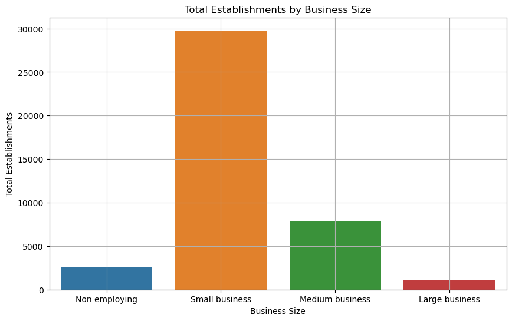

```python
plt.figure(figsize=(10, 6))
sns.barplot(data=Jobs_2022_df, x='business_size', y='total_establishments', estimator=sum, ci=None)
plt.title('Total Establishments by Business Size')
plt.xlabel('Business Size')
plt.ylabel('Total Establishments')
plt.grid(True)
plt.show()
```

## Merging the datasets for further analysis

```python
# Merging the Business and Jobs dataframes on 'CLUE small area'
merged_df = pd.merge(Business_2022_df, Jobs_2022_df, on=['census_year', 'clue_small_area'], how='inner')

# Displaying the first few rows of the merged dataframe
print(f"Merged DataFrame shape: {merged_df.shape}")
print(merged_df.head())
```

```
Merged DataFrame shape: (1280872, 10)
   census_year clue_small_area                  trading_name  \
0         2022       Docklands  Melbourne Private Apartments
1         2022       Docklands  Melbourne Private Apartments
2         2022       Docklands  Melbourne Private Apartments
3         2022       Docklands  Melbourne Private Apartments
4         2022       Docklands  Melbourne Private Apartments

                         business_address  industry_anzsic4_code  \
0  105 Merchant Street DOCKLANDS VIC 3008                   6720
1  105 Merchant Street DOCKLANDS VIC 3008                   6720
2  105 Merchant Street DOCKLANDS VIC 3008                   6720
3  105 Merchant Street DOCKLANDS VIC 3008                   6720
4  105 Merchant Street DOCKLANDS VIC 3008                   6720

  industry_anzsic4_description                      anzsic_indusrty  \
0         Real Estate Services      Accommodation and Food Services
1         Real Estate Services  Administrative and Support Services
2         Real Estate Services    Agriculture, Forestry and Fishing
3         Real Estate Services         Arts and Recreation Services
4         Real Estate Services         Arts and Recreation Services

     business_size  total_establishments  total_jobs
0  Medium business                     7       377.0
1   Large business                     1       219.0
2   Small business                     1       219.0
3   Large business                     3      1443.0
4   Small business                    24       151.0
```

## Plotting Correlation Matrix

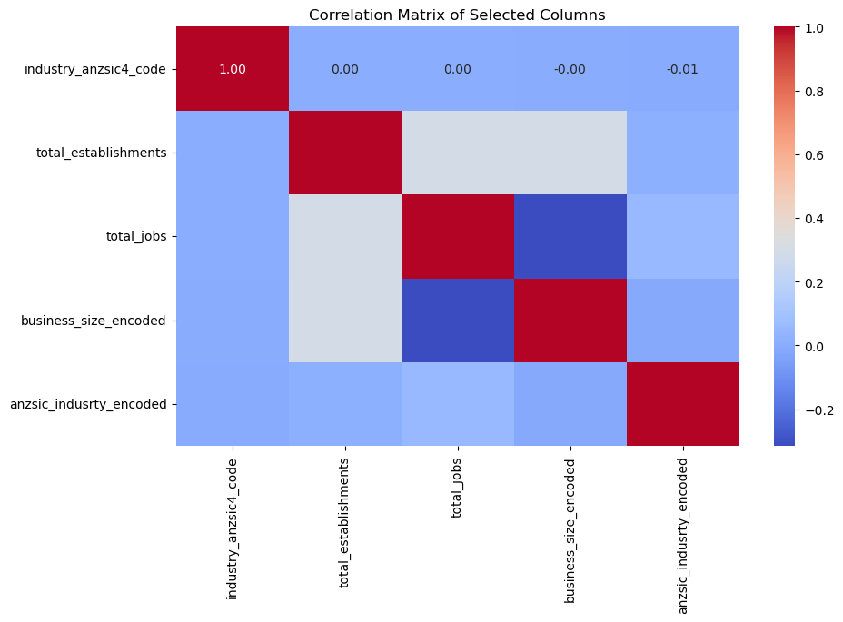

```python
# Create a label encoder instance
le = LabelEncoder()

# Apply label encoding to categorical columns
merged_df['business_size_encoded'] = le.fit_transform(merged_df['business_size'])
merged_df['anzsic_indusrty_encoded'] = le.fit_transform(merged_df['anzsic_indusrty'])

# Select the relevant columns for correlation
corr_columns = ['industry_anzsic4_code', 'total_establishments', 'total_jobs', 'business_size_encoded', 'anzsic_indusrty_encoded']

# Plot the correlation heatmap
plt.figure(figsize=(10, 6))
sns.heatmap(merged_df[corr_columns].corr(), annot=True, cmap='coolwarm', fmt='.2f')
plt.title('Correlation Matrix of Selected Columns')
plt.show()
```

## Implementing Predictive modeling by building Machine Learning Models

## 1. Implementing Linear Regression model and predicting total jobs

```python
# Selecting features and target variable
X = merged_df[['total_establishments', 'business_size_encoded', 'anzsic_indusrty_encoded']]
y = merged_df['total_jobs']

# Splitting the data into training and testing sets
X_train, X_test, y_train, y_test = train_test_split(X, y, test_size=0.3, random_state=42)

# Fitting a Linear Regression model
model = LinearRegression()
model.fit(X_train, y_train)

# Making predictions on the test set
y_pred = model.predict(X_test)

# Print the first 10 predictions and their corresponding actual values
predicted_vs_actual = pd.DataFrame({'Predicted': y_pred[:10], 'Actual': y_test[:10].values})

# Display the predicted vs actual values
print(predicted_vs_actual)
```

```
     Predicted   Actual
0  2687.191708   1950.0
1  2714.062169   1896.0
2   378.304871      0.0
3  5139.567979  25353.0
4  2929.296320   1919.0
5   706.634719      0.0
6   583.852903    900.0
7   959.696573      0.0
8  2597.055783    798.0
9  4392.384944   6434.0
```

## Evaluating Linear Regression using reliable functions

```python
# Calculate Mean Squared Error (MSE)
mse = mean_squared_error(y_test, y_pred)

# Calculate Root Mean Squared Error (RMSE)
rmse = np.sqrt(mse)

# Calculate R-squared (R²)
r2 = r2_score(y_test, y_pred)

# Print the results
print(f"Mean Squared Error (MSE): {mse}")
print(f"Root Mean Squared Error (RMSE): {rmse}")
print(f"R-squared (R²): {r2}")
```

```
Mean Squared Error (MSE): 16575032.640504118
Root Mean Squared Error (RMSE): 4071.2446058305213
R-squared (R²): 0.2685997281706364
```

## 2. Implementing DecisionTree and predicting total jobs

```python
# Decision Tree Regressor
dt_model = DecisionTreeRegressor(random_state=42)
dt_model.fit(X_train, y_train)

# Predict on test set
y_pred_dt = dt_model.predict(X_test)

# Print the first 10 predictions and their corresponding actual values
predicted_vs_actual = pd.DataFrame({'Predicted': y_pred_dt[:10], 'Actual': y_test[:10].values})

# Display the predicted vs actual values
print(predicted_vs_actual)
```

```
   Predicted   Actual
0     1950.0   1950.0
1     1896.0   1896.0
2        0.0      0.0
3    25353.0  25353.0
4     1919.0   1919.0
5        0.0      0.0
6      900.0    900.0
7        0.0      0.0
8      798.0    798.0
9     6434.0   6434.0
```

## Evaluating Decision Tree Model using reliable functions

```python
# Evaluate Decision Tree Model
mse_dt = mean_squared_error(y_test, y_pred_dt)
rmse_dt = np.sqrt(mse_dt)
r2_dt = r2_score(y_test, y_pred_dt)

print("Decision Tree Results")
print(f"Mean Squared Error (MSE): {mse_dt}")
print(f"Root Mean Squared Error (RMSE): {rmse_dt}")
print(f"R-squared (R²): {r2_dt}")
```

```
Decision Tree Results
Mean Squared Error (MSE): 61828.61019803605
Root Mean Squared Error (RMSE): 248.65359478205025
R-squared (R²): 0.9972717120209363
```

## 3. Implementing RandomForestRegressor and predicting total jobs

```python
# Random Forest Regressor
rf_model = RandomForestRegressor(n_estimators=100, random_state=42)
rf_model.fit(X_train, y_train)

# Predict on test set
y_pred_rf = rf_model.predict(X_test)

# Print the first 10 predictions and their corresponding actual values
predicted_vs_actual = pd.DataFrame({'Predicted': y_pred_rf[:10], 'Actual': y_test[:10].values})

# Display the predicted vs actual values
print(predicted_vs_actual)
```

```
   Predicted   Actual
0     1950.0   1950.0
1     1896.0   1896.0
2        0.0      0.0
3    25353.0  25353.0
4     1919.0   1919.0
5        0.0      0.0
6      900.0    900.0
7        0.0      0.0
8      798.0    798.0
9     6434.0   6434.0
```

## Evaluating Random Forest Model using reliable functions

```python
# Evaluate Random Forest Model
mse_rf = mean_squared_error(y_test, y_pred_rf)
rmse_rf = np.sqrt(mse_rf)
r2_rf = r2_score(y_test, y_pred_rf)

print("\nRandom Forest Results")
print(f"Mean Squared Error (MSE): {mse_rf}")
print(f"Root Mean Squared Error (RMSE): {rmse_rf}")
print(f"R-squared (R²): {r2_rf}")
```

```
Random Forest Results
Mean Squared Error (MSE): 61828.75658655659
Root Mean Squared Error (RMSE): 248.6538891442412
R-squared (R²): 0.9972717055613047
```

# Conclusion

### Predictive Modeling Results:

Several machine learning models were applied to predict job creation based on business size, industry classification, and total establishments. Here are the results:

1. **Linear Regression**:
   - The Linear Regression model provided limited predictive power, as indicated by the **R² value of 0.27**, suggesting that a linear relationship alone was insufficient to capture the complexity of job creation patterns.
   - **Evaluation metrics** for Linear Regression:
     - Mean Squared Error (MSE): 16,575,032.64
     - Root Mean Squared Error (RMSE): 4,071.24
     - R-squared (R²): 0.27
2. **Decision Tree Regressor**:
   - The **Decision Tree** model performed exceptionally well, achieving an **R² value of 0.997**, indicating its effectiveness in capturing complex relationships between features such as business size, industry, and total jobs.
   - **Evaluation metrics** for Decision Tree:
     - Mean Squared Error (MSE): 61,828.61
     - Root Mean Squared Error (RMSE): 248.65
     - R-squared (R²): 0.997
3. **Random Forest Regressor**:
   - The **Random Forest** model also performed remarkably well, with an **R² of 0.997**, similar to the Decision Tree model. Given its ensemble nature, Random Forests are more robust and reliable, making them an excellent choice for future predictions.
   - **Evaluation metrics** for Random Forest:
     - Mean Squared Error (MSE): 61,828.75
     - Root Mean Squared Error (RMSE): 248.65
     - R-squared (R²): 0.997

### Final Thoughts:

This use case offers a comprehensive overview of business distribution and employment trends in Melbourne, highlighting key factors that influence job creation. Through advanced machine learning models like **Random Forest**, accurate predictions about employment trends can guide policymakers in making informed decisions about resource allocation and economic support. Supporting large businesses and targeting emerging sectors for growth will be crucial to maintaining a sustainable and thriving economy in Melbourne.